# Variación de la población y migración

# Variación de la población

A continuación, se presenta un análisis de la variación de la población durante el periodo 2022-2023, así como, de la proyección de la población para el 2024 y 2025. Para tal objetivo, se consideran datos de la poblacion por años calendario, según sexo y grupos quinquenales de edades proporcionado por el Instituto Nacional de Estadística y Censos (INEC). Los cuales, son estimaciones calculadas sobre la población esperada en un lapso de 2011-2050.

Primeramente, se identifica la distribución de la población costarricense del último año 2023 según la edad y el sexo.

Mediante la pirámide poblacional se visualiza un comportamiento similar para ambos sexos. Se puede observar unos intervalos de edad dominantes, tanto para hombres como para mujeres corresponde a las personas entre 20 y 35 años. Esto puede sugerir un envejecimiento de la población, pues, la base de la pirámide al ser menos ancha que el centro, puede indicar un baja en la tasa de natalidad y por ende un lento crecimiento de la población. Por otro lado, en ambos sexos, la proporción de personas adultas mayores es pequeña en comparación con la base de la pirámide , pero, dado que el centro es más ancho esto puede indicar cierta estabilidad demográfica.

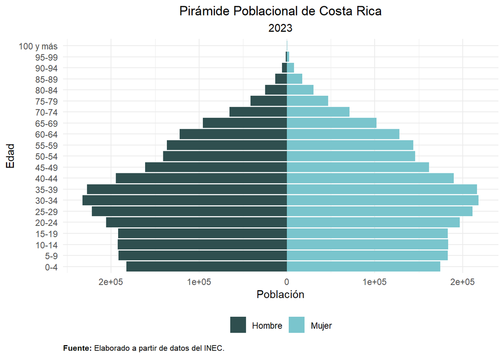

Con el fin de analizar la variación de la población costarricense, se consideran tres rangos de edad por motivos de simplicidad y mayor claridad en el entendimiento de la información. Estos rangos representan a tres sectores principales de la población: personas infantes de 0 a 14 años, personas en edad de trabajar que corresponde al intervalo de 15 a 64 años y como tercer rango, las personas de 65 años y más que conformarían a los pensionados por jubilación.

Para acompañar el análisis de la variación de la población, primero se estudia la composición porcentual de la población por edades. Con el cual, se puede analizar la evolución que presenta cada población.

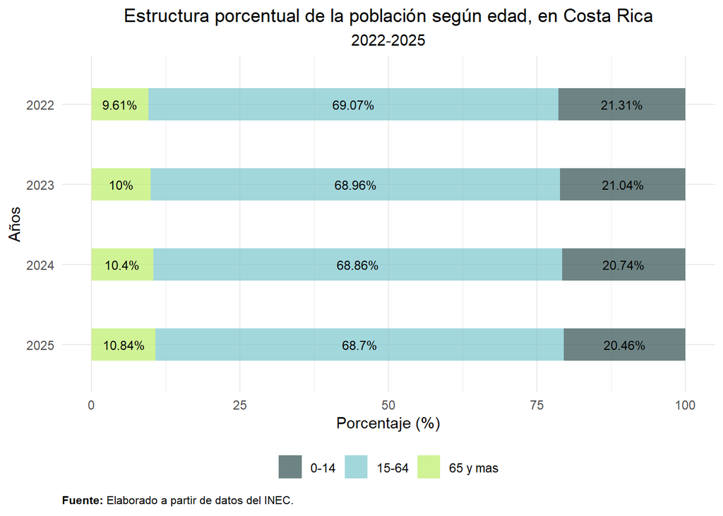

A pesar de que el porcentaje que representa la población entre 15 y 64 años disminuyó del 2022 al 2023, pues, pasó de 69.07% a un 68.96% de la población total y para el 2024 y el 2025 también se proyecta que decrezca su porcentaje de composición, sigue siendo el grupo que mayor proporción muestra.

Seguidamente, en el siguiente gráfico se muestra la variación porcentual en años consecutivos de la población por los rangos de edad mencionados anteriormente.

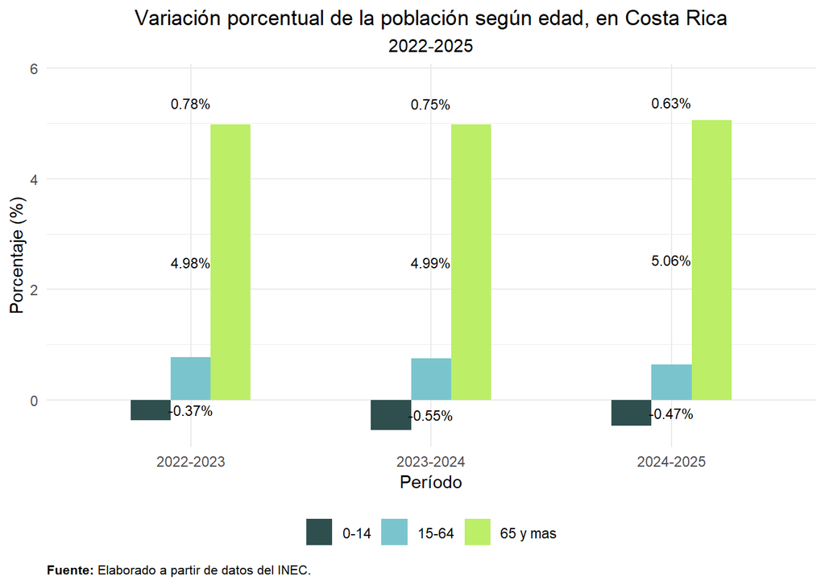

Para el caso de las personas entre los 0 y 14 años se tiene que en el 2023, esta población ha disminuido un 0.37% con respecto al 2022. Además, se proyecta que para el 2024 baje un 0.55% respecto al 2023 y para el 2025 también decrezca pero un 0.47% en comparación con la población del 2024. Esta tendencia a la disminución es coincidente con la vista en el gráfico anterior y se debe a la baja tasa de natalidad que se ha presentado en los últimos años, tal y como se explica en el apartado de fecundidad más adelante.

En cuanto a las personas entre los 15 y 64 años, la variación muestra una tendencia a la baja pero en pequeña medida. Lo cual, evidencia la disminución de su porcentaje en la población total en Costa Rica visto previamente.

Además, los mayores porcentajes de variación los presenta el grupo conformado por las personas adultas mayores. Presentando un aumento de 4.98% en el 2023 y estimándose un incremento de 5.06% para el 2025 en comparación con el 2024.

Dado que se experimentó y se proyectan variaciones negativas para la población de infantes y crecimientos en las poblaciones de edades mayores, esto confirma el envejecimiento de la población que se planeteó en el análisis de la pirámide poblacional. Lo cual, es una problemática para el financiamiento del sistema de pensiones, pues, se preveé que la población económicamente activa disminuya y la cantidad de pensionados aumente, dificultando entonces su solvencia.

# Migración

Como parte del contexto demográfico,se analizan los flujos de migración en Costa Rica en los último dos años. Por lo tanto, mediante datos proporcionados por la Dirección General de Migración y Extranjería (DGME), se estudia el comportamiento de los ingresos y egresos mensuales de personas de diferentes nacionalidades.

En el siguiente gráfico, se visualiza dicho compartamiento durante el periodo en estudio.

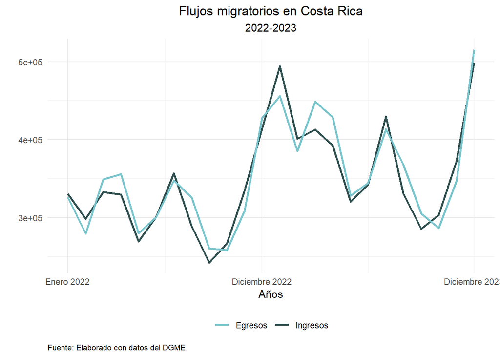

Es posible identificar un comportamiento variado para los ingresos y egresos al país. Durante el periodo se presentan notables subidas y bajadas en el flujo de migración.

Para el 2022, en septiembre se presentó una disminución considerable de las personas que entraron al país, sin embargo, a finales del año tuvo un gran crecimiento pasando de 242322 ingresos a 493908 en enero del 2023. Posteriormente, mostró una tendencia a la baja pero volvió a incrementar a mediados del 2023, en julio específicamente. Y para finales de año incrementó todavía más. El comportamiento general de los ingresos fue de mayores entradas para el 2023 en comporación con el 2022.